# Predicting the class of human activity

## Description of my analysis

The goal of my project is to predict the manner in which the participants in a human activity measurement experiment did their exercise, by relating a class variable to the other variables to predict with.

The data for this project were kindly provided by the people at the [HAR PROJECT](http://groupware.les.inf.puc-rio.br/har).

## Downloading and reading data

The appropriate folder structure is created if not already present. Data are downloaded to obtain the CSV files needed for our analysis. The two datasets `training` and `testing` are populated.

```r
    require(downloader)
```

```r
    dataDir <- paste(getwd(),"\\data",sep="")
    if (!file.exists(dataDir)) {
        dir.create(dataDir)
    }

    ## Training set ##
    fileUrl <- "https://d396qusza40orc.cloudfront.net/predmachlearn/pml-training.csv"
    csvFile <- paste(dataDir,"\\train.csv",sep="")
    if (!file.exists(csvFile)) {
        download(fileUrl, csvFile, mode = "wb")
    }
    training <- read.csv(csvFile)

    ## Test set ##
    fileUrl <- "https://d396qusza40orc.cloudfront.net/predmachlearn/pml-testing.csv"
    csvFile <- paste(dataDir,"\\test.csv",sep="")
    if (!file.exists(csvFile)) {
        download(fileUrl, csvFile, mode = "wb")
    }
    testing <- read.csv(csvFile)
```

## Preprocessing

In the dataset there are 160 columns. I started eliminating:

- columns with too many Na’s
- columns with only empty and / or `#DIV/0!` data
- near zero variance predictors
- strongly correlated predictors (all but one)

Clearly, the strong relationship between `x` and `classe` is only valid in the training set, and it would dramatically distort any prediction. For this reason I removed it.

```r
    dim(training)
```

```
## [1] 19622   160
```

```r
    library(caret)
```

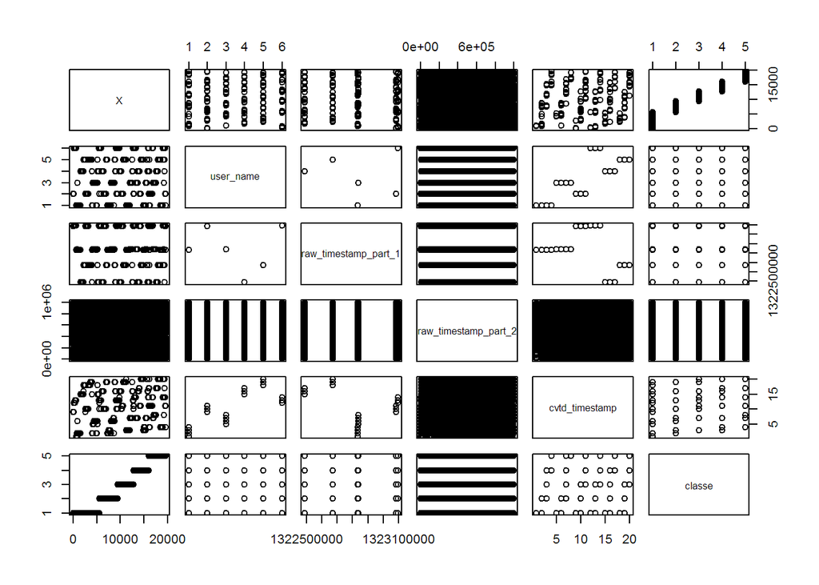

```r
    too.many.nas <- as.vector((apply(is.na(training), 2, sum)/nrow(training))>0.5)
    training <- training[,!too.many.nas]

    div0 <- as.vector(apply((training=="#DIV/0!"), 2, sum)>1)
    training <- training[,!div0]

    nzv <- nearZeroVar(training[1:60], saveMetrics = TRUE)
    training <- training[,!nzv$nzv]

    num.predictors <- training[,-c(1,2,5,59)]
    descrCor <- cor(num.predictors)
    highlyCorDescr <- findCorrelation(descrCor, cutoff = 0.9)
    keep.cols <- setdiff(colnames(training), colnames(descrCor)[highlyCorDescr[-1]])
    training <- training[,keep.cols]

    pairs(training[c(1,2,3,4,5,53)])
```

```r
    training <- training[,-c(1)]

    dim(training)
```

```
## [1] 19622    52
```

## Training the model

The cleaned dataset is splitted into two parts: “true” training set, and validation set. The model is trained by means of the `rpart` function. The tree is pruned with the complexity parameter associated with the smallest cross-validated error.

```r
    library(rpart)
    library(kernlab)
    library(rattle)
    set.seed(888)
    inTrain <- createDataPartition(y=training$classe,p=0.75,list=FALSE)
    validation <- training[-inTrain,]
    training <- training[inTrain,]
    dim(training)
```

```
## [1] 14718    52
```

```r
    dim(validation)
```

```
## [1] 4904   52
```

```r
    fit <- rpart(classe~.,data=training,method="class")

    cp.threshold <- fit$cptable[which.min(fit$cptable[,"xerror"]),"CP"]
    cp.threshold
```

```
## [1] 0.01
```

[figure not shown]

```r
    pfit <- prune(fit,cp=cp.threshold)

    fancyRpartPlot(pfit)
```

## Cross validation and estimate of in- and out of sample error

The prediction based on the trained model is compared to the given values of the predicted variable for the training set. The corresponding in-sample error, estimated as miscalssification rate, is computed.

```r
    t.mis.bool <- predict(pfit,newdata=training,type="vector")!=as.numeric(training$classe)
    sum(t.mis.bool)/nrow(training)
```

```
## [1] 0.1331
```

I expect the out-of-sample error to be larger than this value. In order to ascertain this, I compute the misclassification rate for the validation set.

```r
    v.mis.bool <- predict(pfit,newdata=validation,type="vector")!=as.numeric(validation$classe)
    sum(v.mis.bool)/nrow(validation)
```

```
## [1] 0.1466
```

## Predicting testing values

The value of the predicted variable is computed for the 20 assigned cases.

```r
    pr20 <- predict(pfit,newdata=testing,type="vector")
    factor(levels(training$classe)[pr20])
```

```
##  [1] B A C A A E D C A A B C B A E E A B B B
## Levels: A B C D E
```